# Part I - Prosper Loan

## Introduction

> ```
>  L'ensemble de données Prosper Loan contient 113 937 prêts avec 81 variables sur chaque prêt, y compris le montant du prêt, le  taux d'intérêt , le statut actuel du prêt, le revenu de l'emprunteur et bien d'autres. L'ensemble de données contient des informations sur les prêts entre pairs facilités par la société de crédit Prosper.
> ```

> Je sous-sélectionnerai environ 14 variables à explorer pour cette analyse.

## Preliminary Wrangling

```python
# import all packages and set plots to be embedded inline
import numpy as np
import pandas as pd
import matplotlib.pyplot as plt
import seaborn as sb

import warnings
warnings.filterwarnings('ignore')

%matplotlib inline
```

> Load in your dataset and describe its properties through the questions below. Try and motivate your exploration goals through this section.

```python
df=pd.read_csv('prosperLoanData.csv')
df.head()
```

|  | ListingKey | ListingNumber | ListingCreationDate | CreditGrade | Term | LoanStatus | ClosedDate | BorrowerAPR | BorrowerRate | LenderYield | ... | LP_ServiceFees | LP_CollectionFees | LP_GrossPrincipalLoss | LP_NetPrincipalLoss | LP_NonPrincipalRecoverypayments | PercentFunded | Recommendations | InvestmentFromFriendsCount | InvestmentFromFriendsAmount | Investors |
| --- | --- | --- | --- | --- | --- | --- | --- | --- | --- | --- | --- | --- | --- | --- | --- | --- | --- | --- | --- | --- | --- |
| 0 | 1021339766868145413AB3B | 193129 | 2007-08-26 19:09:29.263000000 | C | 36 | Completed | 2009-08-14 00:00:00 | 0.16516 | 0.1580 | 0.1380 | ... | -133.18 | 0.0 | 0.0 | 0.0 | 0.0 | 1.0 | 0 | 0 | 0.0 | 258 |
| 1 | 10273602499503308B223C1 | 1209647 | 2014-02-27 08:28:07.900000000 | NaN | 36 | Current | NaN | 0.12016 | 0.0920 | 0.0820 | ... | 0.00 | 0.0 | 0.0 | 0.0 | 0.0 | 1.0 | 0 | 0 | 0.0 | 1 |
| 2 | 0EE9337825851032864889A | 81716 | 2007-01-05 15:00:47.090000000 | HR | 36 | Completed | 2009-12-17 00:00:00 | 0.28269 | 0.2750 | 0.2400 | ... | -24.20 | 0.0 | 0.0 | 0.0 | 0.0 | 1.0 | 0 | 0 | 0.0 | 41 |
| 3 | 0EF5356002482715299901A | 658116 | 2012-10-22 11:02:35.010000000 | NaN | 36 | Current | NaN | 0.12528 | 0.0974 | 0.0874 | ... | -108.01 | 0.0 | 0.0 | 0.0 | 0.0 | 1.0 | 0 | 0 | 0.0 | 158 |
| 4 | 0F023589499656230C5E3E2 | 909464 | 2013-09-14 18:38:39.097000000 | NaN | 36 | Current | NaN | 0.24614 | 0.2085 | 0.1985 | ... | -60.27 | 0.0 | 0.0 | 0.0 | 0.0 | 1.0 | 0 | 0 | 0.0 | 20 |

5 rows × 81 columns

```python
df.shape
```

```
(113937, 81)
```

> Les variables que je vais travailler avec sont
> 1. ListingNumber: Nombre dans la liste
> 2. Term : La durée du prêt exprimée en mois.
> 3. LoanStatus : L'état actuel du prêt .
> 4. BorrowerAPR : Le taux annuel effectif global de l'emprunteur pour le prêt.
> 5. ProsperScore : Un score de risque personnalisé construit à l'aide des données historiques de Prosper.
> 6. ListingCategory (numeric) : La catégorie de l'annonce que l'emprunteur a sélectionnée lors de la publication de son annonce
> 7. EmploymentStatus : Le statut d'emploi de l'emprunteur au moment où il a publié l'annonce.
> 8. EmploymentStatusDuration : La durée en mois du statut d'emploi au moment de la création de l'annonce.
> 9. IsBorrowerHomeowner : Un emprunteur sera classé comme propriétaire s'il a une hypothèque sur son profil de crédit ou s'il fournit des documents confirmant qu'il est propriétaire.
> 10. DebtToIncomeRatio : Le ratio dette/revenu de l'emprunteur au moment où le profil de crédit a été tiré.
> 11. StatedMonthlyIncome : Le revenu mensuel déclaré par l'emprunteur au moment de la création de l'annonce.
> 12. LoanOriginalAmount : Le montant initial du prêt.
> 13. LoanOriginationDate : La date à laquelle le prêt a été émis.
> 14. MonthlyLoanPayment : La mensualité prévue du prêt.

```python
variables = ['ListingNumber','Term', 'LoanStatus', 'BorrowerAPR', 'ProsperScore', 'ListingCategory (numeric)', 'EmploymentStatus',
                    'EmploymentStatusDuration', 'IsBorrowerHomeowner', 'DebtToIncomeRatio', 'StatedMonthlyIncome', 'LoanOriginalAmount',
                    'LoanOriginationDate', 'MonthlyLoanPayment']

#extraire les variables que nous voulons utiliser et les stocker dans un dataframe séparé appelé 'new_df'
new_df = df[variables]
new_df.head()
```

|  | ListingNumber | Term | LoanStatus | BorrowerAPR | ProsperScore | ListingCategory (numeric) | EmploymentStatus | EmploymentStatusDuration | IsBorrowerHomeowner | DebtToIncomeRatio | StatedMonthlyIncome | LoanOriginalAmount | LoanOriginationDate | MonthlyLoanPayment |
| --- | --- | --- | --- | --- | --- | --- | --- | --- | --- | --- | --- | --- | --- | --- |
| 0 | 193129 | 36 | Completed | 0.16516 | NaN | 0 | Self-employed | 2.0 | True | 0.17 | 3083.333333 | 9425 | 2007-09-12 00:00:00 | 330.43 |
| 1 | 1209647 | 36 | Current | 0.12016 | 7.0 | 2 | Employed | 44.0 | False | 0.18 | 6125.000000 | 10000 | 2014-03-03 00:00:00 | 318.93 |
| 2 | 81716 | 36 | Completed | 0.28269 | NaN | 0 | Not available | NaN | False | 0.06 | 2083.333333 | 3001 | 2007-01-17 00:00:00 | 123.32 |
| 3 | 658116 | 36 | Current | 0.12528 | 9.0 | 16 | Employed | 113.0 | True | 0.15 | 2875.000000 | 10000 | 2012-11-01 00:00:00 | 321.45 |
| 4 | 909464 | 36 | Current | 0.24614 | 4.0 | 2 | Employed | 44.0 | True | 0.26 | 9583.333333 | 15000 | 2013-09-20 00:00:00 | 563.97 |

```python
new_df.dtypes
```

```
ListingNumber                  int64
Term                           int64
LoanStatus                    object
BorrowerAPR                  float64
ProsperScore                 float64
ListingCategory (numeric)      int64
EmploymentStatus              object
EmploymentStatusDuration     float64
IsBorrowerHomeowner             bool
DebtToIncomeRatio            float64
StatedMonthlyIncome          float64
LoanOriginalAmount             int64
LoanOriginationDate           object
MonthlyLoanPayment           float64
dtype: object
```

```python
new_df.describe()
```

|  | ListingNumber | Term | BorrowerAPR | ProsperScore | ListingCategory (numeric) | EmploymentStatusDuration | DebtToIncomeRatio | StatedMonthlyIncome | LoanOriginalAmount | MonthlyLoanPayment |
| --- | --- | --- | --- | --- | --- | --- | --- | --- | --- | --- |
| count | 1.139370e+05 | 113937.000000 | 113912.000000 | 84853.000000 | 113937.000000 | 106312.000000 | 105383.000000 | 1.139370e+05 | 113937.00000 | 113937.000000 |
| mean | 6.278857e+05 | 40.830248 | 0.218828 | 5.950067 | 2.774209 | 96.071582 | 0.275947 | 5.608026e+03 | 8337.01385 | 272.475783 |
| std | 3.280762e+05 | 10.436212 | 0.080364 | 2.376501 | 3.996797 | 94.480605 | 0.551759 | 7.478497e+03 | 6245.80058 | 192.697812 |
| min | 4.000000e+00 | 12.000000 | 0.006530 | 1.000000 | 0.000000 | 0.000000 | 0.000000 | 0.000000e+00 | 1000.00000 | 0.000000 |
| 25% | 4.009190e+05 | 36.000000 | 0.156290 | 4.000000 | 1.000000 | 26.000000 | 0.140000 | 3.200333e+03 | 4000.00000 | 131.620000 |
| 50% | 6.005540e+05 | 36.000000 | 0.209760 | 6.000000 | 1.000000 | 67.000000 | 0.220000 | 4.666667e+03 | 6500.00000 | 217.740000 |
| 75% | 8.926340e+05 | 36.000000 | 0.283810 | 8.000000 | 3.000000 | 137.000000 | 0.320000 | 6.825000e+03 | 12000.00000 | 371.580000 |
| max | 1.255725e+06 | 60.000000 | 0.512290 | 11.000000 | 20.000000 | 755.000000 | 10.010000 | 1.750003e+06 | 35000.00000 | 2251.510000 |

```python
new_df.isnull().sum()
```

```
ListingNumber                    0
Term                             0
LoanStatus                       0
BorrowerAPR                     25
ProsperScore                 29084
ListingCategory (numeric)        0
EmploymentStatus              2255
EmploymentStatusDuration      7625
IsBorrowerHomeowner              0
DebtToIncomeRatio             8554
StatedMonthlyIncome              0
LoanOriginalAmount               0
LoanOriginationDate              0
MonthlyLoanPayment               0
dtype: int64
```

```python
new_df.duplicated().sum()
```

```
0
```

#### Data Cleaning

```python
#Changer le type de la colonne 'LoanOriginationDate' en datatime
new_df['LoanOriginationDate'] = pd.to_datetime(new_df['LoanOriginationDate'])
#Remplir les valeurs nulles des colonnes
def fill(cols):
    for c in cols:
        new_df[c]=new_df[c].fillna(0)
cols=['ProsperScore','EmploymentStatusDuration','DebtToIncomeRatio']
fill(cols)


new_df['BorrowerAPR'] = new_df['BorrowerAPR'].fillna(new_df['BorrowerAPR'].mean())
new_df['EmploymentStatus'] = new_df['EmploymentStatus'].fillna('unknown')
```

```python
new_df.isnull().sum()
```

```
ListingNumber                0
Term                         0
LoanStatus                   0
BorrowerAPR                  0
ProsperScore                 0
ListingCategory (numeric)    0
EmploymentStatus             0
EmploymentStatusDuration     0
IsBorrowerHomeowner          0
DebtToIncomeRatio            0
StatedMonthlyIncome          0
LoanOriginalAmount           0
LoanOriginationDate          0
MonthlyLoanPayment           0
dtype: int64
```

### What is the structure of your dataset?

> L'ensemble de données Original Prosper contient 113937 prêts avec 81 variables. J'ai sélectionné 14 variables à utiliser pour obtenir une analyse significative.

### What is/are the main feature(s) of interest in your dataset?

> Les principales caractéristiques intéressantes de l'ensemble de données sont la caractéristique BorrowerAPR.

### What features in the dataset do you think will help support your investigation into your feature(s) of interest?

> Toutes les autre caractéristiques à part ListingNumber aideront à soutenir l'enquête sur BorrowerAPR

## Univariate Exploration

> In this section, investigate distributions of individual variables. If you see unusual points or outliers, take a deeper look to clean things up and prepare yourself to look at relationships between variables.

#### 1.BorrowerAPR

la distrubition de la colnne BorrowerAPR ?

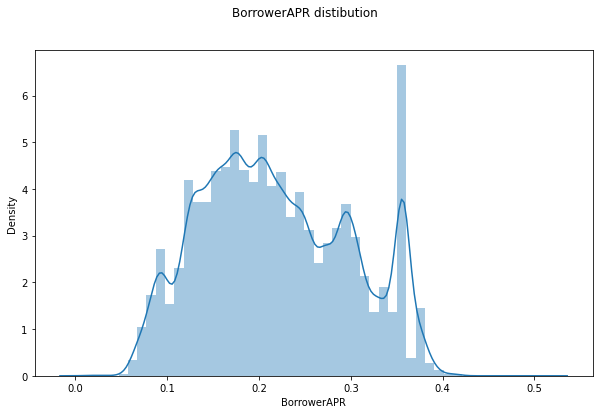

```python
plt.figure(figsize=(10,6))
plt.suptitle("BorrowerAPR distibution")
sb.distplot(new_df['BorrowerAPR']);
```

#### 2. LoanOriginalAmount

Quel est le montant le plus souvent prêté ?

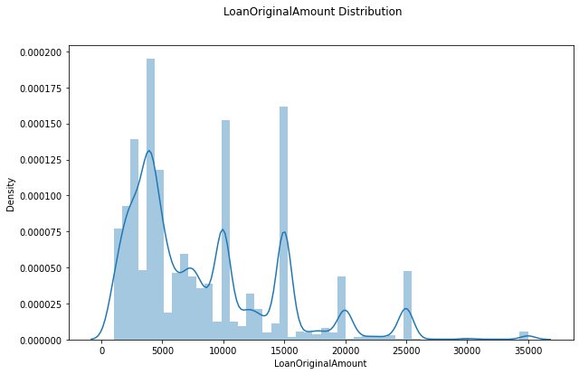

```python
#Distribution du montant de prêt
plt.figure(figsize=(10,6))
plt.suptitle("LoanOriginalAmount Distribution")
sb.distplot(new_df['LoanOriginalAmount']);
```

```python
new_df.LoanOriginalAmount.value_counts().sort_values(ascending=False)
```

```
4000     14333
15000    12407
10000    11106
5000      6990
2000      6067
         ...
17562        1
2984         1
1112         1
13900        1
4292         1
Name: LoanOriginalAmount, Length: 2468, dtype: int64
```

1. Le montant le plus présent est 4000
2. Généralement les montants les plus cités est souvant inférieurs ou égals à 15000

#### 3.Terms

À quelle durée de prêt la majorité des prêts sont-ils soumis ?

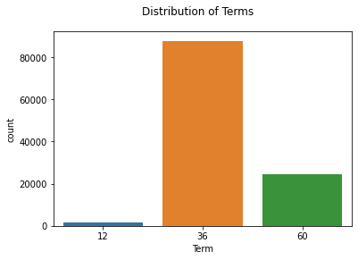

```python
plt.suptitle("Distribution of Terms")
sb.countplot(data = new_df, x = 'Term');
```

Rarement que la durée des prêts est inférieur à un an , elle va jusqu'à 3 ans dans la plupart du temps et même 5 ans dans d'autre cas mais ce cas moins présents .

#### 4.Loan Status

Le statut de la majorité des prêts ?

[figure not shown]

```python
plt.suptitle("Distribution of Terms")
plt.xticks(rotation = 90)
sb.countplot(data = new_df, x = 'LoanStatus');
```

Le status de la majorité des prêts est en cours de prêt et ensuite les prêts complétés

#### 5.ListingCategory

La catogirie des prêts par importance ?

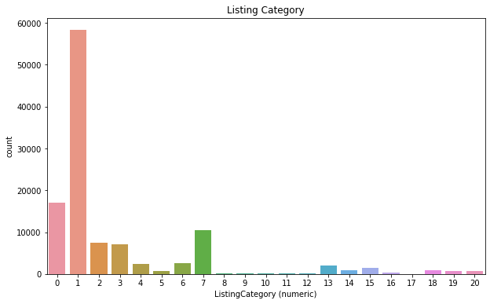

```python
plt.figure(figsize=(10,6))
plt.title("Listing Category")
sb.countplot(new_df["ListingCategory (numeric)"])
```

> Sachant que 0 : Not Available, 1 : Debt Consolidation, 2 : Home Improvement, 3 : Business, 4 : Personal Loan, 5 : Student Use, 6 : Auto, 7: Other, 8 : Baby&Adoption, 9 : Boat, 10 : Cosmetic Procedure, 11 : Engagement Ring, 12 : Green Loans, 13 : Household Expenses, 14 : Large Purchases, 15 : Medical/Dental, 16 : Motorcycle, 17 : RV, 18 : Taxes, 19 : Vacation, 20 : Wedding Loans

#### 6.EmploymentStatus

Le statut d'emploi le plus présent ?

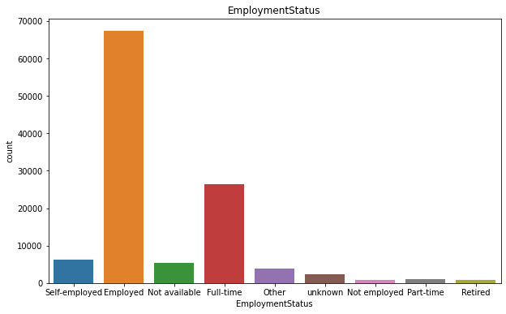

```python
plt.figure(figsize=(10,6))
plt.title("EmploymentStatus")
sb.countplot(new_df.EmploymentStatus)
```

La plupart des emprunteurs sont des employés au moment de publier les prêts

#### 7. IsBorrowerHomeowner

Est-ce que les emprunteurs sont tous des propriètaires ?

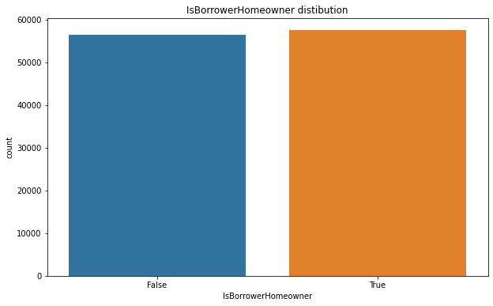

```python
plt.figure(figsize=(10,6))
plt.title("IsBorrowerHomeowner distibution")
sb.countplot(new_df.IsBorrowerHomeowner)
```

On peut déduire que plus d'emprunteurs sont des propriètaires mais pas trop par rapport aux autres

#### 8. StatedMonthlyIncome

La distribution de Revenu mensuel déclaré ?

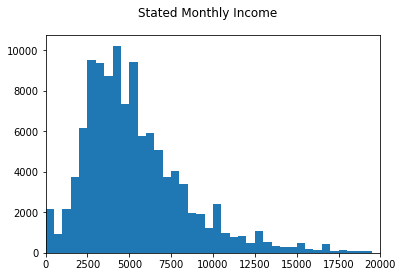

```python
# bins=np.arange(0,new_df.StatedMonthlyIncome.max(),500)
# new_df.StatedMonthlyIncome.plot(kind="hist",bins=bins);
# # plt.suptitle("Stated Monthly Income");


bins= np.arange(0, 20000, 500)
plt.xlim(0,20000)
plt.hist(data=new_df, x='StatedMonthlyIncome', bins= bins);
plt.suptitle("Stated Monthly Income");
```

La distribution des revenus mensuels est asymétrique à droite. Le revenu mensuel le plus fréquent des emprunteurs semble être d'environ 5 000, le revenu mensuel de la plupart des États étant inférieur à 20 000.

### Discuss the distribution(s) of your variable(s) of interest. Were there any unusual points? Did you need to perform any transformations?

> La distribution du taux annuel effectif global des Emprunteurs (BorrowerAPR) semble être multimodale.

### Of the features you investigated, were there any unusual distributions? Did you perform any operations on the data to tidy, adjust, or change the form of the data? If so, why did you do this?

> Avant de faire mes requêtes , j'ai essayé de nettoyer mes données en gérant les valeurs nulls , après j'ai étudié le comportement de 7 variables selon le nombre d'occurances de chaque valeur de ses variables et j'ai obtenu le résultat suivant .

[output not shown]

## Bivariate Exploration

> In this section, investigate relationships between pairs of variables in your data. Make sure the variables that you cover here have been introduced in some fashion in the previous section (univariate exploration).

##### Corrélation entre variables

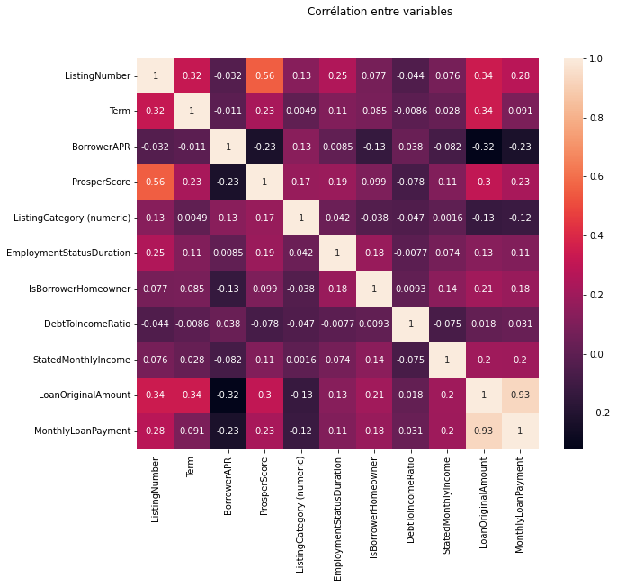

```python
plt.figure(figsize = (10, 8))
sb.heatmap(new_df.corr(), annot=True)
plt.suptitle("Corrélation entre variables");
```

Je vais éxplorer les relations entre deux variables qui sont plus corrélées et je cite

1. BorrowerAPR vs prosperScore (a negative coefficient of -0.23)
2. BorrowerAPR vs LoanOriginalAmount (a negative coefficient of -0.32)
3. BorrowerAPR vs MonthlyLoanPayment (a negative coefficient of -0.23)
4. isBorrowerHomeOwner vs LoanOriginalAmount (a positive coefficient of 0.21)
5. StatedMonthlyIncome vs LoanOriginalAmount ( a positive coefficient of 0.2)
6. StatedMonthlyIncome vs MonthlyLoanPayment (a positive coefficient of 0.2)
7. LoanOriginalAmount vs MonthlyLoanPayment (a positive coefficient of 0.93)

### 1. BorrowerAPR vs prosperScore

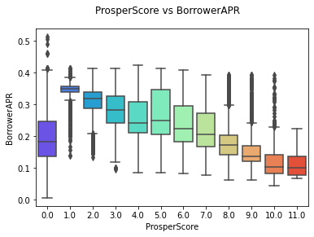

```python
# plt.figure(figsize = [10, 6])
# sb.regplot(x = 'ProsperScore' , y = 'BorrowerAPR', data = new_df, scatter_kws={'alpha':0.01})
# plt.suptitle("BorrowerAPR vs prosperScore");
sb.boxplot(x='ProsperScore',y='BorrowerAPR',data=new_df,palette='rainbow')
plt.suptitle("ProsperScore vs BorrowerAPR");
```

En global plus le score grandit plus le taux diminue

### 2.BorrowerAPR vs LoanOriginalAmount

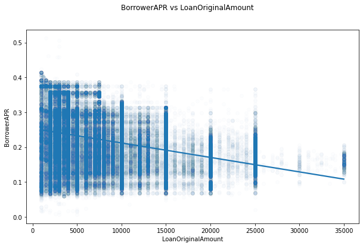

```python
plt.figure(figsize = [10, 6])
sb.regplot(x = 'LoanOriginalAmount' , y = 'BorrowerAPR', data = new_df, scatter_kws={'alpha':0.01})
plt.suptitle("BorrowerAPR vs LoanOriginalAmount");
```

Plus le montant du prêt obtenu est élevé, plus le taux annuel effectif global de l'emprunteur est faible

### 3.BorrowerAPR vs MonthlyLoanPayment

[figure not shown]

```python
plt.figure(figsize = [10, 6])
plt.xlim([0,1500])
sb.regplot(x = 'MonthlyLoanPayment' , y = 'BorrowerAPR', data = new_df, scatter_kws={'alpha':0.01})
plt.suptitle("MonthlyLoanPayment vs LoanOriginalAmount");
```

Plus La mensualité prévue du prêt obtenu est élevé, plus le taux annuel effectif global de l'emprunteur est faible

### 4.isBorrowerHomeOwner vs LoanOriginalAmount

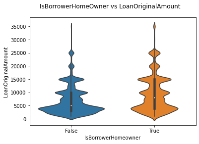

```python
#diagramme de violin
sb.violinplot(data=new_df,x="IsBorrowerHomeowner", y="LoanOriginalAmount" )
plt.suptitle("IsBorrowerHomeOwner vs LoanOriginalAmount");
```

D'après le graphique, il montre que les non-propriétaires ont principalement prêté des montants compris entre 0 et 5 000 . Alors que la plupart des propriétaires étaient répartis sur différents montants .

#### StatedMonthlyIncome vs LoanOriginalAmount

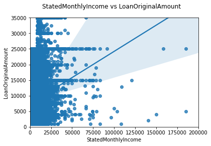

```python
sb.regplot( data = new_df, x= 'StatedMonthlyIncome', y = 'LoanOriginalAmount')
plt.xlim([0, 200000])
plt.ylim([0, new_df.LoanOriginalAmount.max()])
plt.suptitle("StatedMonthlyIncome vs LoanOriginalAmount");
```

Les emprunteurs ayant un revenu mensuel plus élevé ont des montants de prêt plus élevés

#### StatedMonthlyIncome vs MonthlyLoanPayment

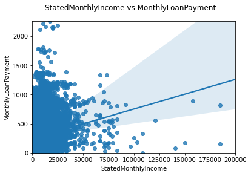

```python
sb.regplot( data = new_df, x= 'StatedMonthlyIncome', y = 'MonthlyLoanPayment')
plt.xlim([0, 200000])
plt.ylim([0, new_df.MonthlyLoanPayment.max()])
plt.suptitle("StatedMonthlyIncome vs MonthlyLoanPayment");
```

Les emprunteurs dont le revenu mensuel est plus élevé sont en mesure de rembourser des mensualités de prêt plus élevées.

#### LoanOriginalAmount vs MonthlyLoanPayment

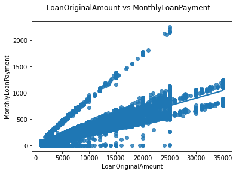

```python
sb.regplot(x = 'LoanOriginalAmount', y = 'MonthlyLoanPayment', data = new_df)
plt.suptitle("LoanOriginalAmount vs MonthlyLoanPayment");
```

Plus le montant du prêt est élevé, plus le montant du remboursement mensuel est élevé

### Talk about some of the relationships you observed in this part of the investigation. How did the feature(s) of interest vary with other features in the dataset?

> Le taux de l'emprunteur est négativement corrélé au montant initial du prêt, au ProsperScore et au paiement mensuel du prêt. Les emprunteurs dont le revenu mensuel est plus élevé ont des montants de prêt plus élevés. Les emprunteurs dont le revenu mensuel est plus élevé sont en mesure de rembourser des mensualités de prêt plus élevées. Plus le montant du prêt est élevé, plus le montant du remboursement mensuel est élevé

## Multivariate Exploration

> Create plots of three or more variables to investigate your data even further. Make sure that your investigations are justified, and follow from your work in the previous sections.

Vu que la durée du prêt n'a été présente dans aucune étude précédente je vais éxplorer: L'effet de la durée sur le montant du prêt et le pourcentage du taux annuel de l'emprunteur (Term vs LoanOriginalAmount vs BorrowerAPR ) L'effet de la durée sur le montant du prêt et le paiement mensuel du prêt (Term vs LoanOriginalAmount vs MonthlyLoanPayment )

#### Term vs LoanOriginalAmount vs BorrowerAPR

```
Int64Index([36, 60, 12], dtype='int64')
```

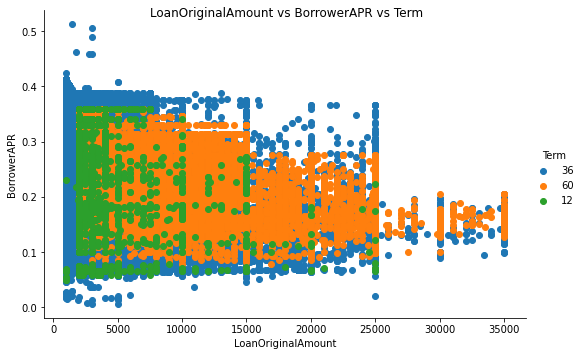

```python
print(new_df.Term.value_counts().index)
val = sb.FacetGrid(data = new_df, hue = 'Term',hue_order = new_df.Term.value_counts().index, size = 5, aspect = 1.5)
val.map(plt.scatter, 'LoanOriginalAmount', 'BorrowerAPR')
val.add_legend()
plt.suptitle("LoanOriginalAmount vs BorrowerAPR vs Term");
```

Les prêts à terme de 36 mois ont un pourcentage de taux annuel des emprunteurs compris entre 0 et 0,4 avec quelques valeurs aberrantes allant à 0,5, les prêts à terme de 60 mois sont davantage concentrés sur les montants de prêt les plus élevés et les BorrowerAPR entre 0,1 et 0,35, tandis que la durée du prêt de 12 mois est principalement pour des montants de prêt inférieurs avec un BorrowerAPR entre 0 et 0,35.

#### Term vs LoanOriginalAmount vs MonthlyLoanPayment

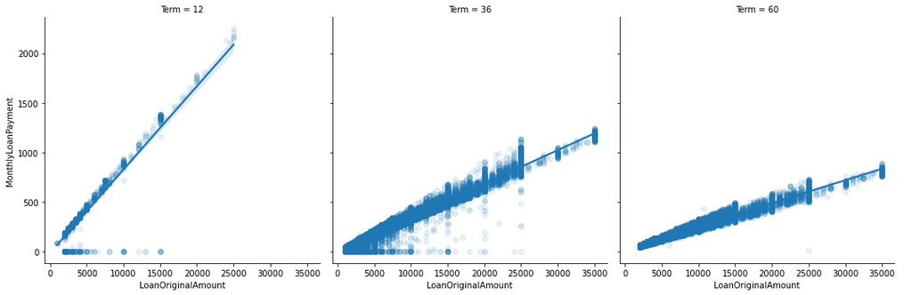

```python
val=sb.FacetGrid(data=new_df, height=5, col='Term')
val.map(sb.regplot, 'LoanOriginalAmount', 'MonthlyLoanPayment', x_jitter=0.04, scatter_kws={'alpha':0.1});
val.add_legend()
# plt.title("LoanOriginalAmount vs MonthlyLoanPayment vs Term", loc="center");
```

Pour les prêts qui ne couvrent que 12 mois, les frais mensuels ont tendance à être plus élevés que les autres termes car il s'agit d'un terme plus court. Alors que les prêts sont plus étalés pour des durées de prêt de 60 mois.

### Talk about some of the relationships you observed in this part of the investigation. Were there features that strengthened each other in terms of looking at your feature(s) of interest?

> Les prêts à terme de 36 mois ont un taux de pourcentage annuel des emprunteurs compris entre 0 et 0,4 avec quelques valeurs aberrantes allant à 0,5, les prêts à terme de 60 mois sont davantage concentrés sur les montants de prêt les plus élevés et les BorrowerAPR entre 0,1 et 0,35, tandis que la durée du prêt de 12 mois est principalement pour les montants de prêt inférieurs avec un BorrowerAPR entre 0 et 0,35. Bien que le terme n'ait pas de relation significative avec la force des effets sur le taux annuel en pourcentage des emprunteurs.

### Were there any interesting or surprising interactions between features?

> L'effet des conditions du prêt sur le paiement mensuel du prêt à rembourser en fonction du montant du prêt a été une découverte intéressante. Pour les prêts qui ne couvrent que 12 mois, les frais mensuels ont tendance à être plus élevés que les autres termes puisqu'il s'agit d'un terme plus court. Alors que les prêts sont plus étalés pour des durées de prêt de 60 mois.

## Conclusions

> Pour ce projet, je me suis concentré sur l'exploration de la découverte des facteurs qui ont des effets sur le pourcentage du taux annuel des emprunteurs.

> Tout d'abord, j'ai sélectionné 14 variables sur les 81 variables d'origine, puis j'ai commencé à explorer la distribution des variables une par une à l'aide de tracés d'histogrammes pour les variables continues et de counplots pour les variables discrètes et normales.

> Ensuite, j'ai utilisé un graphique de régression par rapport au montant du prêt et au pourcentage du taux annuel de l'emprunteur car c'est le facteur le plus évident. Puis divers tracés comme des boxplots, des violin plots, des barplots pour trouver la relation entre deux variables.

> Enfin, d'après mes conclusions dans l'analyse bivariée, il est déterminé que les caractéristiques les plus fortes qui affectent le pourcentage de taux annuel des emprunteurs sont le LoanOriginalAmount, le prosperScore et le MonthlyLoanPayment.

>

> At the end of your report, make sure that you export the notebook as an html file from the `File > Download as... > HTML or PDF` menu. Make sure you keep track of where the exported file goes, so you can put it in the same folder as this notebook for project submission. Also, make sure you remove all of the quote-formatted guide notes like this one before you finish your report!